# The 2017 Halloween Candy Hierarchy Ranking

[figure not shown]

## What do we know?

- Online Survey Conducted in 2017 to see how people feel about different types of candies
- Over 100 Candy types given as an option
- Almost 2500 voters participated
- How do the voters feel?
  - JOY, MEH or DESPAIR
- Other datas collected include age, gender, state and country

# Which candies are most popular?

```python
candyData.sample(3)
```

| Internal ID | Going_out | Gender | Age | Q4: COUNTRY | Q5: STATE, PROVINCE, COUNTY, ETC | Q6 \| 100 Grand Bar | Q6 \| Anonymous brown globs that come in black and orange wrappers (a.k.a. Mary Janes) | Q6 \| Any full-sized candy bar | Q6 \| Black Jacks | Q6 \| Bonkers (the candy) | Q6 \| Bonkers (the board game) | Q6 \| Bottle Caps | Q6 \| Box'o'Raisins | Q6 \| Broken glow stick | Q6 \| Butterfinger | Q6 \| Cadbury Creme Eggs | Q6 \| Candy Corn | Q6 \| Candy that is clearly just the stuff given out for free at restaurants | Q6 \| Caramellos | Q6 \| Cash, or other forms of legal tender | Q6 \| Chardonnay | Q6 \| Chick-o-Sticks (we donÕt know what that is) | Q6 \| Chiclets | Q6 \| Coffee Crisp | Q6 \| Creepy Religious comics/Chick Tracts | ... | Q6 \| Sweetums (a friend to diabetes) | Q6 \| Take 5 | Q6 \| Tic Tacs | … |
| --- | --- | --- | --- | --- | --- | --- | --- | --- | --- | --- | --- | --- | --- | --- | --- | --- | --- | --- | --- | --- | --- | --- | --- | --- | --- | --- | --- | --- | --- | --- |
| 90277271 | No | Female | 57 | USA | Kansas | JOY | DESPAIR | JOY | DESPAIR | MEH | MEH | MEH | MEH | MEH | JOY | DESPAIR | MEH | MEH | JOY | JOY | JOY | DESPAIR | JOY | DESPAIR | DESPAIR | ... | DESPAIR | MEH | JOY | … |
| 90275215 | No | Male | 51 | Usa | Pa | JOY | MEH | JOY | DESPAIR | MEH | DESPAIR | MEH | MEH | DESPAIR | JOY | JOY | JOY | MEH | JOY | DESPAIR | JOY | MEH | JOY | MEH | DESPAIR | ... | DESPAIR | JOY | MEH | … |
| 90273687 | Yes | Female | 11 | North Carolina | USA | DESPAIR | DESPAIR | JOY | MEH | MEH | MEH | MEH | DESPAIR | DESPAIR | DESPAIR | MEH | MEH | MEH | JOY | JOY | MEH | DESPAIR | MEH | MEH | DESPAIR | ... | MEH | DESPAIR | DESPAIR | … |

3 rows × 119 columns

# Cleaning activities

We will clean the Going out, Gender and Age columns first

- Remove Strings from Age column
- Dealing with outliers
- Filling NA values
- Some participants in the survey entered decimals, fractions and some ranges as age
  - 24-50, 45-55, 39.4 and 70 1/2 are some examples
- Survey Participants mean age is 42

# Cleaning Country

- This survey was avaliable Worldwide
- Many different participants from around the World
- We are only interested in USA and Canada data
- Data from other country will be droped
- Structural Errors
  - Inconsistent capitalization and Typos
  - Many different entries for USA
    - few examples are (U.S.A, usa, US of A, America, etc.)

# Cleaning State, Province and County

- Inconsistency with many of the data
- People entering City or County
- We want to narrow it down to States
- Many entering both the abbreviation and full State name
- We will create key value pair for every state and city in the USA
- Replace all inconsistent entry with correct abbriviation by searchng the dictionary

```python
candyData.sample(3)
```

| Internal ID | Going_out | Gender | Age | Q4: COUNTRY | Q5: STATE, PROVINCE, COUNTY, ETC | Q6 \| 100 Grand Bar | Q6 \| Anonymous brown globs that come in black and orange wrappers (a.k.a. Mary Janes) | Q6 \| Any full-sized candy bar | Q6 \| Black Jacks | Q6 \| Bonkers (the candy) | Q6 \| Bonkers (the board game) | Q6 \| Bottle Caps | Q6 \| Box'o'Raisins | Q6 \| Broken glow stick | Q6 \| Butterfinger | Q6 \| Cadbury Creme Eggs | Q6 \| Candy Corn | Q6 \| Candy that is clearly just the stuff given out for free at restaurants | Q6 \| Caramellos | Q6 \| Cash, or other forms of legal tender | Q6 \| Chardonnay | Q6 \| Chick-o-Sticks (we donÕt know what that is) | Q6 \| Chiclets | Q6 \| Coffee Crisp | Q6 \| Creepy Religious comics/Chick Tracts | ... | Q6 \| Sweetums (a friend to diabetes) | Q6 \| Take 5 | Q6 \| Tic Tacs | … |
| --- | --- | --- | --- | --- | --- | --- | --- | --- | --- | --- | --- | --- | --- | --- | --- | --- | --- | --- | --- | --- | --- | --- | --- | --- | --- | --- | --- | --- | --- | --- |
| 90283989 | No | Male | 71 | USA | CO | MEH | DESPAIR | JOY | MEH | DESPAIR | DESPAIR | DESPAIR | DESPAIR | DESPAIR | JOY | JOY | MEH | DESPAIR | NaN | JOY | JOY | DESPAIR | MEH | DESPAIR | DESPAIR | ... | MEH | MEH | DESPAIR | … |
| 90289284 | No | Male | 47 | USA | CA | MEH | DESPAIR | MEH | MEH | JOY | DESPAIR | MEH | DESPAIR | DESPAIR | JOY | DESPAIR | DESPAIR | DESPAIR | DESPAIR | JOY | JOY | MEH | MEH | MEH | DESPAIR | ... | MEH | JOY | MEH | … |
| 90282167 | Yes | Male | 46 | USA | CA | JOY | MEH | JOY | DESPAIR | MEH | DESPAIR | MEH | DESPAIR | DESPAIR | JOY | MEH | MEH | DESPAIR | JOY | JOY | JOY | MEH | DESPAIR | DESPAIR | DESPAIR | ... | DESPAIR | JOY | DESPAIR | … |

3 rows × 119 columns

# Gender Distribution Plot

```
array([<matplotlib.axes._subplots.AxesSubplot object at 0x1a28b162e8>],
      dtype=object)
```

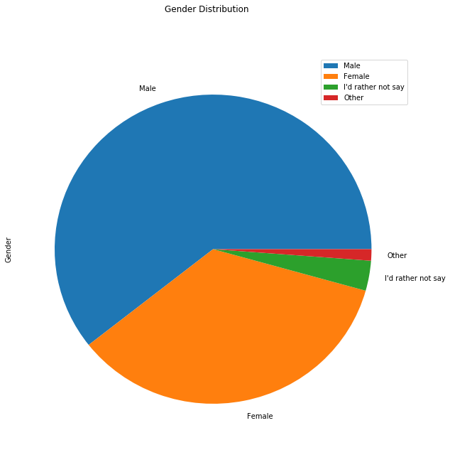

```python
matplotlib.rcParams['figure.figsize'] = 10, 10
gender_count_df.plot.pie(subplots=True,title='Gender Distribution')
```

# Candy scores and ranking for USA and Canada

```python
candyScore = candyRank.sum()
candyScore_df = pd.DataFrame(data=candyScore, columns=['score'])
candyScore_df.sort_values(by = ['score'], ascending = False)
```

|  | score |
| --- | --- |
| Q6 \| Any full-sized candy bar | 4599.0 |
| Q6 \| ReeseÕs Peanut Butter Cups | 4430.0 |
| Q6 \| Kit Kat | 4370.0 |
| Q6 \| Cash, or other forms of legal tender | 4341.0 |
| Q6 \| Twix | 4279.0 |
| ... | ... |
| Q6 \| Kale smoothie | 455.0 |
| Q6 \| Real Housewives of Orange County Season 9 Blue-Ray | 386.0 |
| Q6 \| Gum from baseball cards | 333.0 |
| Q6 \| White Bread | 310.0 |
| Q6 \| Broken glow stick | 165.0 |

103 rows × 1 columns

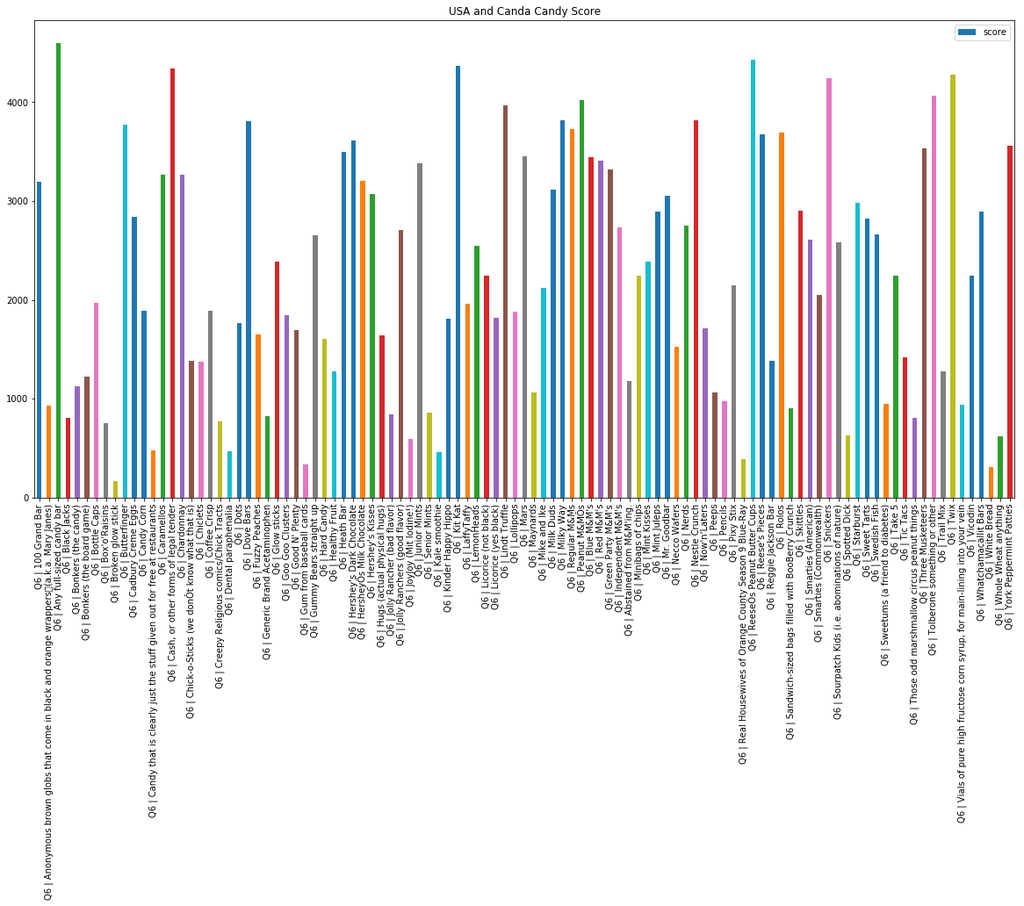

```python
matplotlib.rcParams.update({'font.size': 10})
matplotlib.rcParams['figure.figsize'] = 20, 10
candyScore_df.plot(kind='bar',y='score',title='USA and Canda Candy Score')
```

# Candy scores and ranking for Colorado

```python
CO_Score = CO_Rank.sum()
CO_Score_df = pd.DataFrame(data=CO_Score, columns=['score'])
CO_Score_df.sort_values(by = ['score'], ascending = False)
```

|  | score |
| --- | --- |
| Q6 \| Any full-sized candy bar | 137.0 |
| Q6 \| ReeseÕs Peanut Butter Cups | 136.0 |
| Q6 \| Peanut M&MÕs | 135.0 |
| Q6 \| Kit Kat | 132.0 |
| Q6 \| Cash, or other forms of legal tender | 132.0 |
| ... | ... |
| Q6 \| Spotted Dick | 12.0 |
| Q6 \| Gum from baseball cards | 9.0 |
| Q6 \| Real Housewives of Orange County Season 9 Blue-Ray | 8.0 |
| Q6 \| Broken glow stick | 7.0 |
| Q6 \| White Bread | 6.0 |

102 rows × 1 columns

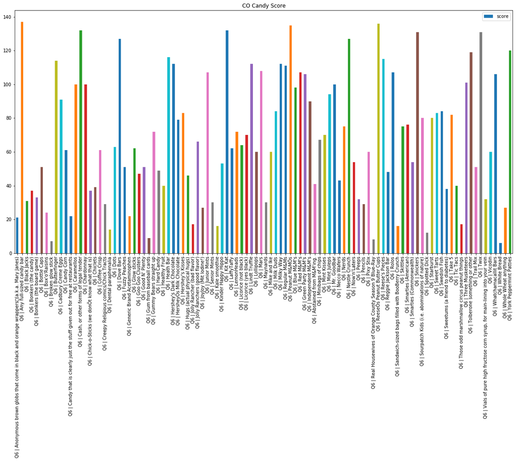

```python
CO_Score_df.plot(kind='bar',y='score',title='CO Candy Score')
```

# Participants ranking by Gender

```python
CO_Gender_Rank['score'] = CO_Gender_Rank[col_list].sum(axis=1)
CO_Gender_Score = CO_Gender_Rank.drop(CO_Gender_Rank[col_list], axis=1, inplace=False)
CO_Gender_Score
```

| Internal ID | Gender | score |
| --- | --- | --- |
| 90272853 | Male | 0.0 |
| 90272881 | Male | 134.0 |
| 90272901 | Male | 208.0 |
| 90273053 | Female | 108.0 |
| 90273058 | Male | 131.0 |
| ... | ... | ... |
| 90290159 | Male | 161.0 |
| 90298440 | Female | 108.0 |
| 90302275 | Female | 0.0 |
| 90305572 | Male | 148.0 |
| 90311056 | Male | 125.0 |

72 rows × 2 columns

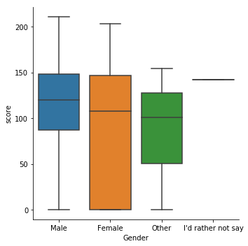

```python
sns.catplot(x="Gender", y="score", kind="box", data=CO_Gender_Rank);
```